# Zadanie domowe nr 2

Kacper Prorok

2023-10-27

## Zadanie 1

Stosowanie `lapply()` do obliczenia podstawowych statystych opisowych

```r
#średnia

lapply(lista2,mean,na.rm=T)
```

```
## $dane1
## [1] 5.5
##
## $dane2
## [1] 0
```

```r
#Odchylenie standardowe

lapply(lista2,sd,na.rm=T)
```

```
## $dane1
## [1] 3.02765
##
## $dane2
## [1] 3.316625
```

```r
#Kwantyle

lapply(lista2,quantile,na.rm=T)
```

```
## $dane1
##    0%   25%   50%   75%  100%
##  1.00  3.25  5.50  7.75 10.00
##
## $dane2
##   0%  25%  50%  75% 100%
## -5.0 -2.5  0.0  2.5  5.0
```

Aby rozwiązać problem wartości brakujących, użyłem argumentu funkcji `na.rm=T`.

## Zadanie 2

Użycie funkcji `sapply()` do obliczenia `max()` oraz `min()`

```r
(sapply(lista4, max))
```

```
## dane1 dane2 dane3
##    20    10     5
```

```r
(sapply(lista4, min))
```

```
## dane1 dane2 dane3
##     1     1     1
```

Dla porówniania wynik funkcji `lapply()`

```r
(lapply(lista4, max))
```

```
## $dane1
## [1] 20
##
## $dane2
## [1] 10
##
## $dane3
## [1] 5
```

**Uwaga 1:** Wynikiem działania funkcji `sapply()` jest tablica, wektor lub macierz, natomiast funkcja `lapply()` zwraca listę.

**Uwaga 2:**

Budowanie funkcji mierzącej *współczynnik zmienności*.

```r
funkcja_zmiennosc = function(szym){
  return(sd(szym,na.rm=T)/mean(szym,na.rm=T))
}
```

Dla podanej niżej funkcji mogę użyć funkcję `sapply()`, co jest widoczne na przykładzie poniżej.

```r
sapply(lista4,funkcja_zmiennosc)
```

```
##     dane1     dane2     dane3
## 0.5634362 0.5504819 0.5270463
```

## Zadanie 3

Funkcja `apply()` jest używana do stosowania funkcji do wierszy lub kolumn macierzy lub ramki danych. Zwraca wektor, listę albo tablicę.Przykład użycia na wierszach(drugi argument funkcji równy `1`):

```r
df <- data.frame(a = c(1, 2, 3), b = c(4, 5, 6))


result <- apply(df, 1, funkcja_zmiennosc)
result
```

```
## [1] 0.8485281 0.6060915 0.4714045
```

W tym przykładzie użyliśmy wcześniej zdefiniowanej funkcji `funkcja_zmiennosc` aby użyć jej do każdego wiersza ramki danych. Przykład użycia na kolumach(drugi argument funkcji równy `2`):

```r
df <- data.frame(a = c(1, 2, 3), b = c(4, 5, 6))


result <- apply(df, 2, funkcja_zmiennosc)
result
```

```
##   a   b
## 0.5 0.2
```

## Zadanie 4

**a.** Oglądanie zestawu `mtcars`

```r
head(mtcars)
```

```
##                    mpg cyl disp  hp drat    wt  qsec vs am gear carb
## Mazda RX4         21.0   6  160 110 3.90 2.620 16.46  0  1    4    4
## Mazda RX4 Wag     21.0   6  160 110 3.90 2.875 17.02  0  1    4    4
## Datsun 710        22.8   4  108  93 3.85 2.320 18.61  1  1    4    1
## Hornet 4 Drive    21.4   6  258 110 3.08 3.215 19.44  1  0    3    1
## Hornet Sportabout 18.7   8  360 175 3.15 3.440 17.02  0  0    3    2
## Valiant           18.1   6  225 105 2.76 3.460 20.22  1  0    3    1
```

**b.** Użycie funkcji `tapply()`, aby uzyskać informację o przeciętnym spalaniu w zależności od liczby cylindrów

```r
#średnie spalania pogrupowane ze względu na ilość cylindrów
tapply(mtcars$mpg,mtcars$cyl, mean)
```

```
##        4        6        8
## 26.66364 19.74286 15.10000
```

*Pierwszy argument funkcji `tapply()` to zmienna, której statystykę chcemy otrzymać. Drugim argumentem jest zmienna, która będzie służyć do grupowania. Natiomiast trzeci argument to funkcja, która zostanie użyta na podany wektor w pierwszym argumencie.*

**c.** Wyświetlanie podstawowych statystyk opisowych w/w problemu

```r
tapply(mtcars$mpg,mtcars$cyl, summary)
```

```
## $`4`
##    Min. 1st Qu.  Median    Mean 3rd Qu.    Max.
##   21.40   22.80   26.00   26.66   30.40   33.90
##
## $`6`
##    Min. 1st Qu.  Median    Mean 3rd Qu.    Max.
##   17.80   18.65   19.70   19.74   21.00   21.40
##
## $`8`
##    Min. 1st Qu.  Median    Mean 3rd Qu.    Max.
##   10.40   14.40   15.20   15.10   16.25   19.20
```

## Zadanie 5

Wyświetlanie danych przedstawionych w ramce `ascobme`

```r
head(anscombe)
```

```
##   x1 x2 x3 x4   y1   y2    y3   y4
## 1 10 10 10  8 8.04 9.14  7.46 6.58
## 2  8  8  8  8 6.95 8.14  6.77 5.76
## 3 13 13 13  8 7.58 8.74 12.74 7.71
## 4  9  9  9  8 8.81 8.77  7.11 8.84
## 5 11 11 11  8 8.33 9.26  7.81 8.47
## 6 14 14 14  8 9.96 8.10  8.84 7.04
```

*Ramka danych `anscombe` zawiera 11 obserwacji dla każdej z 8 zmiennych. Przedstawiają one 4 zestawy zmiennych x-y, które mają identyczne statystyki opisowe(np.średnia każdej z kolumn “y” wynosi 7,5)*

Wyświetlanie danych w ramce danych `fgl`

```r
library(MASS)
head(fgl)
```

```
##      RI    Na   Mg   Al    Si    K   Ca Ba   Fe type
## 1  3.01 13.64 4.49 1.10 71.78 0.06 8.75  0 0.00 WinF
## 2 -0.39 13.89 3.60 1.36 72.73 0.48 7.83  0 0.00 WinF
## 3 -1.82 13.53 3.55 1.54 72.99 0.39 7.78  0 0.00 WinF
## 4 -0.34 13.21 3.69 1.29 72.61 0.57 8.22  0 0.00 WinF
## 5 -0.58 13.27 3.62 1.24 73.08 0.55 8.07  0 0.00 WinF
## 6 -2.04 12.79 3.61 1.62 72.97 0.64 8.07  0 0.26 WinF
```

*Ramka danych `fgl` zawiera 214 wierszy i 10 kolumn. Znajdują się w niej informacje o pierwiastkach,które zostały pobrane z fragmentów szkła podczas prac kryminalistycznych. Te dane będę analizował w kolejnych podpunktach.*

**a./b.** Przed wyliczeniem średnich sprawdzam jakie kolumny są numeryczne, aby następnie użyć funkcji `apply()` do wyznaczenia średnich w tych kolumnach.

```r
str(dane)
```

```
## 'data.frame':    214 obs. of  10 variables:
##  $ RI  : num  3.01 -0.39 -1.82 -0.34 -0.58 ...
##  $ Na  : num  13.6 13.9 13.5 13.2 13.3 ...
##  $ Mg  : num  4.49 3.6 3.55 3.69 3.62 3.61 3.6 3.61 3.58 3.6 ...
##  $ Al  : num  1.1 1.36 1.54 1.29 1.24 1.62 1.14 1.05 1.37 1.36 ...
##  $ Si  : num  71.8 72.7 73 72.6 73.1 ...
##  $ K   : num  0.06 0.48 0.39 0.57 0.55 0.64 0.58 0.57 0.56 0.57 ...
##  $ Ca  : num  8.75 7.83 7.78 8.22 8.07 8.07 8.17 8.24 8.3 8.4 ...
##  $ Ba  : num  0 0 0 0 0 0 0 0 0 0 ...
##  $ Fe  : num  0 0 0 0 0 0.26 0 0 0 0.11 ...
##  $ type: Factor w/ 6 levels "WinF","WinNF",..: 1 1 1 1 1 1 1 1 1 1 ...
```

```r
apply(dane[1:9],2,mean)
```

```
##          RI          Na          Mg          Al          Si           K
##  0.36542056 13.40785047  2.68453271  1.44490654 72.65093458  0.49705607
##          Ca          Ba          Fe
##  8.95696262  0.17504673  0.05700935
```

**c.** Wyznaczenie mediany dla każdej z tych kolumn

```r
apply(dane[1:9],2,median)
```

```
##     RI     Na     Mg     Al     Si      K     Ca     Ba     Fe
## -0.320 13.300  3.480  1.360 72.790  0.555  8.600  0.000  0.000
```

Największa różnica między medianą, a średnią występuje w kolumnie *Mg*, i wynosi ona ok. 0,8.

```r
#Odchylenie standardowe
lapply(dane[1:9], sd)
```

```
## $RI
## [1] 3.036864
##
## $Na
## [1] 0.8166036
##
## $Mg
## [1] 1.442408
##
## $Al
## [1] 0.4992696
##
## $Si
## [1] 0.7745458
##
## $K
## [1] 0.6521918
##
## $Ca
## [1] 1.423153
##
## $Ba
## [1] 0.4972193
##
## $Fe
## [1] 0.0974387
```

```r
#współczynnik zmienności
lapply(dane[1:9],funkcja_zmiennosc)
```

```
## $RI
## [1] 8.310599
##
## $Na
## [1] 0.06090488
##
## $Mg
## [1] 0.5373031
##
## $Al
## [1] 0.3455377
##
## $Si
## [1] 0.0106612
##
## $K
## [1] 1.312109
##
## $Ca
## [1] 0.158888
##
## $Ba
## [1] 2.840494
##
## $Fe
## [1] 1.709171
```

## Zadanie 6

Instalowanie pakietów `tidyr`,`dplyr` oraz `gapminder` za pomocą funkcji `instal.packages()`, a następnie wczytanie ich za pomocą funkcji `library()`

```r
install.packages("tidyr")
install.packages("dplyr")
install.packages("gapminder")
```

```r
library(tidyr)
library(dplyr)
library(gapminder)
```

**a.** Zmiana nazwy zmiennych. Użyję funkcji `rename()`.

```r
dane1<-gapminder%>%
  rename(rok=year, PKB=gdpPercap)
colnames(dane1)
```

```
## [1] "country"   "continent" "rok"       "lifeExp"   "pop"       "PKB"
```

**b.** Zmiana wartości zmiennej `pop`, aby ludność była przedstawiona w milionach osób. Użyję funkcji `mutate()`, która pozwala mi wykonywać działania na wszystkich wierszach w wybranej kolummnie.

```r
dane1<-dane1%>%
  mutate(pop=pop/1000000)
```

**c.** Wyświetlenie wszystkich krajów afrykańskich, które w roku 1957 miały PKB większe niż 12 000$.

```r
dane1%>%
  filter(continent=="Africa",rok==1957,PKB>12000)
```

```
## # A tibble: 0 × 6
## # ℹ 6 variables: country <fct>, continent <fct>, rok <int>, lifeExp <dbl>,
## #   pop <dbl>, PKB <dbl>
```

*W 1957 żaden kraj w Afryce nie miał PKB większego od 12 000 $*

Rysowanie wykresu, który przedstawia jak zmieniała się liczba krajów z w/w wymaganiami.

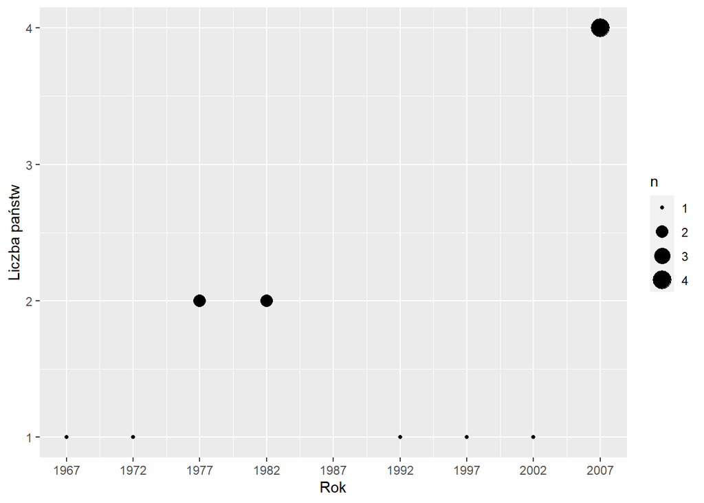

```r
rok_1957<-dane1%>%
  filter(continent=="Africa",PKB>12000)%>%
  count(rok)
library(ggplot2)

ggplot(rok_1957)+
  geom_point(mapping = aes(x = rok, y = n,
                           size=n))+
   scale_x_continuous(breaks = seq(1967, 2022, by = 5)) +
  labs(x = "Rok", y = "Liczba państw")
```

*Widzimy, że dopiero w roku 1967 pojawił się pierwszy afrykański kraj z PKB większym niż 12 000 $*

**d.** Kraje spoza Afryki, które w roku 1962 miały PKB mniejsze od 750$

```r
dane1%>%
  filter(continent!="Africa",rok==1962,PKB<750)
```

```
## # A tibble: 6 × 6
##   country    continent   rok lifeExp    pop   PKB
##   <fct>      <fct>     <int>   <dbl>  <dbl> <dbl>
## 1 Bangladesh Asia       1962    41.2  56.8   686.
## 2 Cambodia   Asia       1962    43.4   6.08  497.
## 3 China      Asia       1962    44.5 666.    488.
## 4 India      Asia       1962    43.6 454     658.
## 5 Myanmar    Asia       1962    45.1  23.6   388
## 6 Nepal      Asia       1962    39.4  10.3   652.
```

**e.** Sprawdzamy ile wyniosła przeciętna długość życia w Polsce w latach 1952,1977 i 2002.

```r
lata<-c("1977","2002","1952")
Polska<-dane1%>%
  filter(rok %in% lata,country=="Poland")%>%
  select(rok,country,lifeExp)
Polska
```

```
## # A tibble: 3 × 3
##     rok country lifeExp
##   <int> <fct>     <dbl>
## 1  1952 Poland     61.3
## 2  1977 Poland     70.7
## 3  2002 Poland     74.7
```

Teraz sprawdzimy, w których krajach obu Ameryk była ona większa. Zaczniemy od roku 1952.

```r
Ameryki_1952<-dane1%>%
  filter(rok==1952,continent=="Americas",lifeExp>Polska$lifeExp[1])%>%
  select(country,lifeExp)
Ameryki_1952
```

```
## # A tibble: 6 × 2
##   country       lifeExp
##   <fct>           <dbl>
## 1 Argentina        62.5
## 2 Canada           68.8
## 3 Paraguay         62.6
## 4 Puerto Rico      64.3
## 5 United States    68.4
## 6 Uruguay          66.1
```

Rok 1977.

```r
Ameryki_1977<-dane1%>%
  filter(rok==1977,continent=="Americas",lifeExp>Polska$lifeExp[2])%>%
  select(country,lifeExp)
Ameryki_1977
```

```
## # A tibble: 5 × 2
##   country       lifeExp
##   <fct>           <dbl>
## 1 Canada           74.2
## 2 Costa Rica       70.8
## 3 Cuba             72.6
## 4 Puerto Rico      73.4
## 5 United States    73.4
```

Rok 2002.

```r
Ameryki_2002<-dane1%>%
  filter(rok==2002,continent=="Americas",lifeExp>Polska$lifeExp[3])%>%
  select(country,lifeExp)
Ameryki_2002
```

```
## # A tibble: 9 × 2
##   country       lifeExp
##   <fct>           <dbl>
## 1 Canada           79.8
## 2 Chile            77.9
## 3 Costa Rica       78.1
## 4 Cuba             77.2
## 5 Mexico           74.9
## 6 Panama           74.7
## 7 Puerto Rico      77.8
## 8 United States    77.3
## 9 Uruguay          75.3
```

Wnioskiem jest to, że z biegiem lat zwiększa się oczekiwana długość życia, co wynika z postępu medycznego oraz zbogacania się krajów. Należy też zwrócić uwagę, że porównując rok 1952 oraz 2002, możemy zauważyć, że w Amerykach przybyło krajów, które mają większą niż Polska oczekiwaną długość życia. Może to świadczyć o tym, że system medyczny w obu Amerykach rozwijał się szybciej niż w Polsce.

**f.** Wyznaczanie podstawowych statystyk opisowych dotyczących populacji na różnych kontynentach w roku 2007.(populacja w mln)

```r
populacja2007<-dane1%>%
  filter(rok==2007)%>%
  select(pop,continent)%>%
  group_by(continent)%>%
  summarise("mean"=mean(pop),
            "sd"=sd(pop),
            "min"=min(pop),
            "max"=max(pop),
            "me"=median(pop))
populacja2007
```

```
## # A tibble: 5 × 6
##   continent  mean    sd   min    max    me
##   <fct>     <dbl> <dbl> <dbl>  <dbl> <dbl>
## 1 Africa     17.9  24.9 0.200  135.  10.1
## 2 Americas   36.0  68.8 1.06   301.   9.32
## 3 Asia      116.  290.  0.709 1319.  24.8
## 4 Europe     19.5  23.6 0.302   82.4  9.49
## 5 Oceania    12.3  11.5 4.12    20.4 12.3
```

**g.** Wyznaczenie po trzech krajów z Afryki,Europy i Azji, które mają największą oczekiwaną długość życia, pod warunkiem że PKB<5000 $.

```r
ZYCIE<-dane1%>%
  filter(continent!="Americas",rok==1977,PKB<5000)%>%
  group_by(continent)%>%
  top_n(3,lifeExp)%>%
  arrange(continent)
ZYCIE
```

```
## # A tibble: 9 × 6
## # Groups:   continent [3]
##   country                continent   rok lifeExp    pop   PKB
##   <fct>                  <fct>     <int>   <dbl>  <dbl> <dbl>
## 1 Mauritius              Africa     1977    64.9  0.913 3711.
## 2 Reunion                Africa     1977    67.1  0.492 4320.
## 3 Tunisia                Africa     1977    59.8  6.01  3121.
## 4 Korea, Dem. Rep.       Asia       1977    67.2 16.3   4106.
## 5 Malaysia               Asia       1977    65.3 12.8   3828.
## 6 Sri Lanka              Asia       1977    65.9 14.1   1349.
## 7 Albania                Europe     1977    68.9  2.51  3533.
## 8 Bosnia and Herzegovina Europe     1977    69.9  4.09  3528.
## 9 Turkey                 Europe     1977    59.5 42.4   4269.
```

**e.** Podział na kraje RWPG oraz kraje UE

```r
kraje_rwpg <- c("Albania","Bulgaria","Czech Republic","Slovak Republic","Hungary","Poland","Romania","Ukraine","Belarus","Russia","Estonia","Lithuania","Latvia","Moldova")
kraje_ue <- c("Croatia","Finland","Belgium","Denmark","Austria","France","Germany","Greece","Ireland","Italy","Luxembourg","Netherlands","Portugal","Spain","Sweden","United Kingdom")
podzial_1987<-dane1%>%
  filter(continent=="Europe",rok==1987)%>%
  mutate(system=case_when(country%in%kraje_ue~"UE",country%in%kraje_rwpg~"RWPG"))
head(podzial_1987)
```

```
## # A tibble: 6 × 7
##   country                continent   rok lifeExp   pop    PKB system
##   <fct>                  <fct>     <int>   <dbl> <dbl>  <dbl> <chr>
## 1 Albania                Europe     1987    72    3.08  3739. RWPG
## 2 Austria                Europe     1987    74.9  7.58 23688. UE
## 3 Belgium                Europe     1987    75.4  9.87 22526. UE
## 4 Bosnia and Herzegovina Europe     1987    71.1  4.34  4314. <NA>
## 5 Bulgaria               Europe     1987    71.3  8.97  8240. RWPG
## 6 Croatia                Europe     1987    71.5  4.48 13823. UE
```

Teraz wyznaczymy podstawowe statystyki opisowe dla krajów RWPG.

```r
podzial_1987%>%
  filter(system=="RWPG")%>%
  select(lifeExp,pop,PKB)%>%
  summary()
```

```
##     lifeExp           pop              PKB
##  Min.   :69.53   Min.   : 3.075   Min.   : 3739
##  1st Qu.:70.28   1st Qu.: 7.086   1st Qu.: 8661
##  Median :71.08   Median :10.312   Median : 9696
##  Mean   :70.87   Mean   :14.085   Mean   :10299
##  3rd Qu.:71.46   3rd Qu.:16.650   3rd Qu.:12512
##  Max.   :72.00   Max.   :37.741   Max.   :16310
```

Oraz dla krajów UE.

```r
podzial_1987%>%
  filter(system=="UE")%>%
  select(lifeExp,pop,PKB)%>%
  summary()
```

```
##     lifeExp           pop              PKB
##  Min.   :71.52   Min.   : 3.540   Min.   :13039
##  1st Qu.:74.81   1st Qu.: 6.353   1st Qu.:15943
##  Median :75.01   Median : 9.915   Median :21665
##  Mean   :75.34   Mean   :24.297   Mean   :19994
##  3rd Qu.:76.55   3rd Qu.:47.255   3rd Qu.:23619
##  Max.   :77.19   Max.   :77.718   Max.   :25116
```

Oczywiste wnioski, jakie narzucają się po analizie tych danych, to m.in.: znacząca różnica w PKB oraz oczekiwanej długości życia. Wiąże się to oczywiście z tym, że kraje Unii Europejskiej były dużo bardziej rozwinięte oraz bogatsze niż kraje “wschodu”, w których wtedy panował komunizm.

## Zadanie 7

**a.** Rysowanie wykresu liniowego, który przedstawia w jaki sposób zmieniała się oczekiwana długość życia we Włoszech, Niemczech i Japoni.

```r
library(ggplot2)
kraje<-c("Italy","Germany","Japan")
trzech1<-dane1%>%
  filter(country%in%kraje)%>%
  select(country,rok,lifeExp)%>%
  spread(key = rok,value = lifeExp)
```

Używam tutaj funkcji `spread()`, lecz do rysowania wykresu łatwiej mi jest użyć postaci wąskiej.

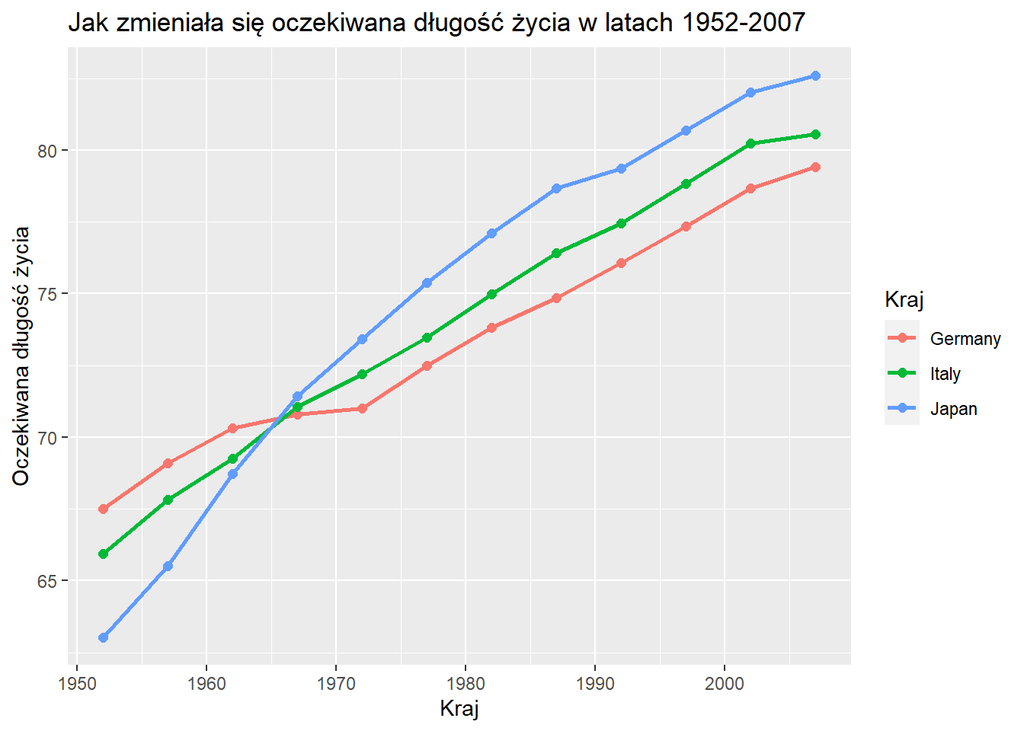

```r
 trzech<-dane1%>%
  filter(country%in%kraje)%>%
  select(country,rok,lifeExp)


wykres<-trzech%>%
  ggplot(aes(x=rok,y=lifeExp,col=country))+
  geom_line(linewidth=1)+
  geom_point(size=2)+
  labs(title="Jak zmieniała się oczekiwana długość życia w latach 1952-2007",
       x="Kraj",
       y="Oczekiwana długość życia")+
  scale_color_discrete(name = "Kraj")

print(wykres)
```

## Zadanie 8

**a.** Funkcja `set.seed()`, służy m.in. do tego, aby dostać uzyskać dokładnie te same wyniki losowania za każdym razem. Funkcja ta, może przydać się w momencie gdy chcemy porównać jakieś modele i potrzebujemy tych samych próbek losowych. Może być przydatna również w sytuacji, gdy chcemy naprawić jakiś błąd.

Teraz zasymulujemy rzuty kostką sześcienną, a następnie użyjemy funkcji `mean()`do wyznaczenia średniej w każdym doświadczeniu.

```r
proba1<-sample(1:6,2,replace = T)
proba2<-sample(1:6,10,replace = T)
proba3<-sample(1:6,50,replace = T)
proba4<-sample(1:6,100,replace = T)
proba5<-sample(1:6,1000,replace = T)

wyniki1<-table(proba1)
wyniki2<-table(proba2)
wyniki3<-table(proba3)
wyniki4<-table(proba4)
wyniki5<-table(proba5)
```

Teraz zobaczmy, jakie liczby uzyskaliśmy w probie 5.

```r
wyniki5
```

```
## proba5
##   1   2   3   4   5   6
## 157 177 159 169 163 175
```

Obliczanie średniej dla każdego doświadczenia.

```r
mean(proba1)
```

```
## [1] 5.5
```

```r
mean(proba2)
```

```
## [1] 3.7
```

```r
mean(proba3)
```

```
## [1] 3.3
```

```r
mean(proba4)
```

```
## [1] 3.28
```

```r
mean(proba5)
```

```
## [1] 3.529
```

Metoda *Monte Carlo* polega na generowaniu dużej ilości liczb losowych w celu przybliżonego rozwiązania różnych problemów matematycznych. Za jej pomocą można np.: obliczyć całki oznaczone,analizować ryzyko i finanse albo też obliczyć wartość oczekiwaną.

**b.** Dwa zespoły NBA, Chicago Bulls i NY Knicks, rozgrywają serię play-off składającą się z siedmiu meczów. Knicks są lepsi i mają 65% szans na wygranie każdego meczu. Rywalizacja toczy się do czterech zwycięstw. Przeprowadzić 10000 symulacji i sprawdzić jak często NY wygra rywalizację.

```r
wygraneNY<-0
wygraneCB<-0

for(i in 1:10000){
  losowanie<-sample(c("Bulls","Knicks"),7,prob = c(0.35,0.65),replace = T)
  if(sum(losowanie=="Knicks")>=4){
    wygraneNY<-wygraneNY+1
  }else{
    wygraneCB<-wygraneCB+1
  }
}
cat("New York Knicks wygrało: ",wygraneNY," razy","\n")
```

```
## New York Knicks wygrało:  8019  razy
```

```r
cat("Chicago Bulls wygrało: ",wygraneCB," razy")
```

```
## Chicago Bulls wygrało:  1981  razy
```

## Zadanie 9

Wczytywanie ramek danych `mammals` oraz `Animals2`

```r
library(MASS)
library(robustbase)
head(mammals)
```

```
##                    body brain
## Arctic fox        3.385  44.5
## Owl monkey        0.480  15.5
## Mountain beaver   1.350   8.1
## Cow             465.000 423.0
## Grey wolf        36.330 119.5
## Goat             27.660 115.0
```

```r
head(Animals2)
```

```
##                     body brain
## Mountain beaver     1.35   8.1
## Cow               465.00 423.0
## Grey wolf          36.33 119.5
## Goat               27.66 115.0
## Guinea pig          1.04   5.5
## Dipliodocus     11700.00  50.0
```

**a.** Konstruowanie wektora `zwierzaki`, który zawiera nazw zwierząt wspólnych dla obu ramek danych.

```r
#1 SPOSÓB
mammals1<-data.frame(rownames(mammals))
colnames(mammals1)[1]<-"zwierzeta"
animals2<-data.frame(rownames(Animals2))
colnames(animals2)[1]<-"zwierzeta"
zwierzaki<-inner_join(mammals1,animals2,by="zwierzeta")
count(zwierzaki)
```

```
##    n
## 1 58
```

```r
#2 SPOSÓB
zwierzaki1<-intersect(mammals1,animals2)
count(zwierzaki1)
```

```
##    n
## 1 58
```

**b.** Użycie funkcji `setdiff()`, aby wyświetlić zwierzęta obecne w zestawie `mammals`, których nie ma w zestawe `Animals2`

```r
setdiff(mammals1,animals2)
```

```
##                zwierzeta
## 1             Arctic fox
## 2 Arctic ground squirrel
## 3           Patas monkey
## 4               Mole rat
```

**c.** Użycie funkcji `setdiff()`, aby wyświetlić zwierzęta obecne w zestawie `Animals2`, których nie ma w zestawe `mammals`

```r
setdiff(animals2,mammals1)
```

```
##               zwierzeta
## 1           Dipliodocus
## 2          Potar monkey
## 3           Triceratops
## 4         Brachiosaurus
## 5                  Mole
## 6             Artic fox
## 7 Artic ground squirrel
```

## Zadanie 10

**a.** Użycie funkcji `qnorm()` do wyznaczenia kwantyla 5% i 95 % dla rozkładu N(0,1)

```r
qnorm(0.05,mean = 0,sd = 1)
```

```
## [1] -1.644854
```

```r
qnorm(0.95,0,1)
```

```
## [1] 1.644854
```

**b.** Użycie funkcji `qt()` do wyznaczenia kwantyla 5% i 95% dla rozkładu t-Studenta

```r
qt(0.05,df=1)
```

```
## [1] -6.313752
```

```r
qt(0.95,df = 1)
```

```
## [1] 6.313752
```

**c.** Zmiana liczby stopni swobody

```r
qt(0.05,df=5)
```

```
## [1] -2.015048
```

```r
qt(0.05,df=10)
```

```
## [1] -1.812461
```

```r
qt(0.05,df=30)
```

```
## [1] -1.697261
```

```r
qt(0.05,df=50)
```

```
## [1] -1.675905
```

```r
qt(0.05,df=1000)
```

```
## [1] -1.646379
```